# Fit MOSM GP to 2-band synthetic example

This notebook contains the workflow for:

- loading groundtruth 2-band (MOGP) time-series,
- fitting a multicomponent MOSM GP model,
- drawing posterior predictive samples,
- visualising the posteriors.

```r
library(here)
library(tidyr)
library(ggplot2)
library(cmdstanr)
library(posterior)
library(bayesplot)
library(readr)
library(glue)
library(jsonlite)
library(MCMCpack) # rdirichlet()
library(dplyr)

register_knitr_engine(override = FALSE)

theme_set(theme_bw())
color_scheme_set("viridis")

source(here("mogp-utils.R"))

filename_stub <- "D2-Q2-seed8641-n400-mnar0.2-noise0.05"

EXECUTE_SAMPLING <- FALSE

N_CHAINS <- 6
N_WARMUP <- 1000
N_SAMPLES <- 1000
```

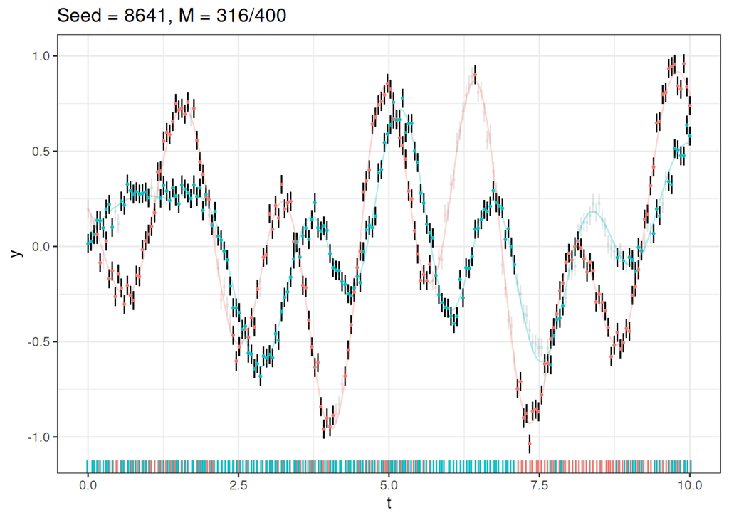

```r
raw_df <- read_csv(
  here("data", glue("{filename_stub}-sim.csv")),
  col_types = "ddddfl",
  show_col_types = FALSE)

input_params <- read_json(
  here("data", glue("{filename_stub}-param.json")),
  simplifyVector = TRUE)

raw_df |>
  ggplot() +
  aes(x = t, colour = d, alpha = ifelse(masked, 0.2, 1)) +
  geom_linerange(aes(ymax = y + y_se, ymin = y - y_se), colour = "black") +
  geom_point(aes(y = y), size = 0.5) +
  geom_line(aes(y = f), linewidth = 0.5, alpha = 0.3) +
  geom_rug(aes(y = y), sides = "b", position = "jitter") +
  labs(title = glue("Seed = {input_params$seed}, M = {sum(!raw_df$masked)}/{NROW(raw_df)}")) +
  theme(legend.position = "none")
```

Notes on data:

```r
input_params
```

```
$seed
[1] 8641

$w
     [,1]   [,2]
[1,]  1.0 0.8944
[2,]  0.7 0.5000

$mu
     [,1] [,2]
[1,]  1.5  1.6
[2,]  4.0  4.1

$Sigma
     [,1]   [,2]
[1,] 0.01 0.0144
[2,] 0.04 0.0400

$theta
     [,1] [,2]
[1,]    0  0.5
[2,]    0 -0.3

$phi
     [,1] [,2]
[1,]    0    0
[2,]    0    0
```

# Model Fitting

```r
stan_model <- cmdstan_model(here("stan", "mosmgp-D2-Q.stan"))
```

```r
if (FALSE) {
  # Fully sampled, noise free dataset
  input_df <- raw_df |>
    mutate(y = f,
           y_se = 0,
           masked = FALSE)
} else {
  input_df <- raw_df |>
    filter(!masked)
}
```

```r
# Within-band standardisation
band1_df <- filter(input_df, d == 1)
band1_f_mean <- mean(band1_df$f)
band1_f_sd <- sd(band1_df$f)
band1_y_mean <- mean(band1_df$y)
band1_y_sd <- sd(band1_df$y)

band1_df$f_std <- (band1_df$f - band1_f_mean)/band1_f_sd
band1_df$y_std <- (band1_df$y - band1_y_mean)/band1_y_sd
band1_df$y_se_std <- band1_df$y_se/band1_y_sd


band2_df <- filter(input_df, d == 2)
band2_f_mean <- mean(band2_df$f)
band2_f_sd <- sd(band2_df$f)
band2_y_mean <- mean(band2_df$y)
band2_y_sd <- sd(band2_df$y)

band2_df$f_std <- (band2_df$f - band2_f_mean)/band2_f_sd
band2_df$y_std <- (band2_df$y - band2_y_mean)/band2_y_sd
band2_df$y_se_std <- band2_df$y_se/band2_y_sd

input_df$f_std <- c(band1_df$f_std, band2_df$f_std)
input_df$y_std <- c(band1_df$y_std, band2_df$y_std)
input_df$y_se_std <- c(band1_df$y_se_std, band2_df$y_se_std)
```

## Sampling

```r
D <- 2L
Q <- 2L

T_range <- diff(range(input_df$t))

ell_min <- median( diff( sort(input_df$t)) )
ell_max <- T_range/4
ell_loc <- log(sqrt(ell_min * ell_max)) # for log-normal prior
theta_max <- T_range

ell_scale <- 1
signal_sd_scale <- 1
mu_scale <- 3
theta_scale <- 1

print(
  glue("ell_min = {ell_min}\nell_max = {ell_max} \nell_loc = {ell_loc} \nell_scale = {ell_scale}, \nsignal_sd_scale = {signal_sd_scale} \nmu-scale = {mu_scale} \ntheta_max = {theta_max}  \ntheta_scale = {theta_scale}"))
```

```
ell_min = 0.050251256281407
ell_max = 2.5
ell_loc = -1.03721449992815
ell_scale = 1,
signal_sd_scale = 1
mu-scale = 3
theta_max = 10
theta_scale = 1
```

## Prior predictive

```r
cfg <- list(
  Q = Q,
  ell_min = ell_min,
  ell_max = ell_max,
  ell_loc = ell_loc,
  ell_scale = ell_scale,
  signal_sd_scale = signal_sd_scale,
  dir_conc = 0.8,
  mu_scale = mu_scale,
  theta_scale = theta_scale,
  theta_max = ell_max
)

prior_draws <- prior_predictive(cfg, tstart = 0, tend = 10, n_per_band = 200, n_draws = 50)
```

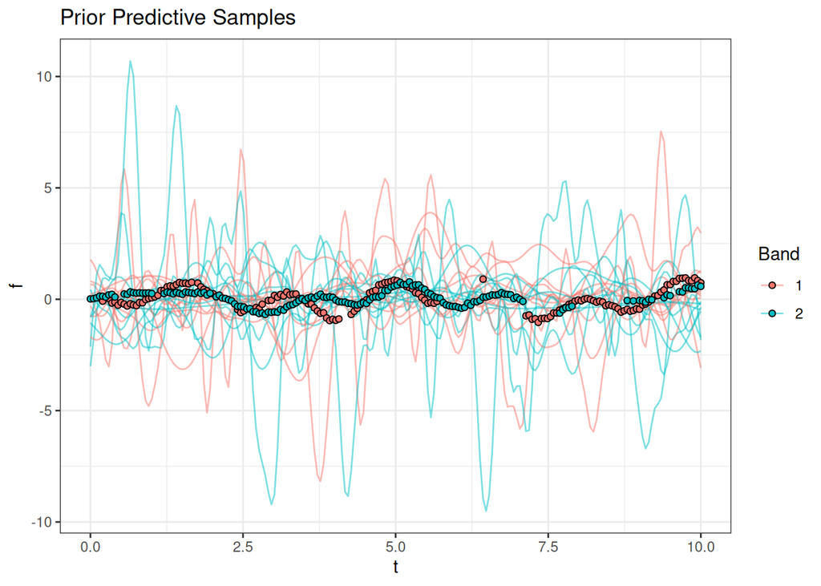

```r
ggplot() +
  geom_line(data = prior_draws |> filter(.draw %in% sample.int(50, 10)),
            mapping = aes(x = t, y = f, colour = d, group = interaction(d,.draw)),
            alpha = 0.5) +
  geom_point(data = input_df,
             mapping = aes(x = t, y = y, fill = d), shape = 21, size = 1.5) +
  #facet_wrap(vars(d), nrow = 2, scales = "free_y") +
  labs(colour = "Band", fill = "Band", y = "f",
       title = "Prior Predictive Samples")
```

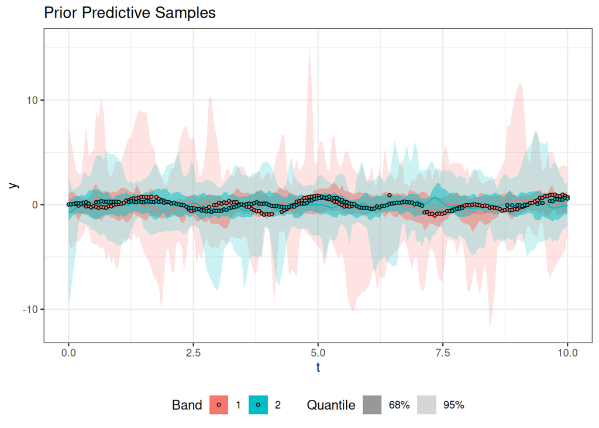

```r
prior_draws |>
  summarise(.by = c(d, t),
            Mean = mean(f),
            Q2.5 = quantile(f, probs = 0.025),
            Q97.5 = quantile(f, probs = 0.975),
            Q16 = quantile(f, probs = 0.16),
            Q84 = quantile(f, probs = 0.84)) |>
  ggplot() +
  aes(x = t, fill = d) +
  geom_ribbon(aes(ymin = Q2.5, ymax = Q97.5, alpha = "95%")) +
  geom_ribbon(aes(ymin = Q16, ymax = Q84, alpha = "68%")) +
  geom_line(aes(colour = d, y = Mean), alpha = 1) +
  geom_point(data = input_df, mapping = aes(x = t, y = y, fill = d), shape = 21, size = 1) +
  scale_alpha_manual(values = c(`95%` = 0.2, `68%` = 0.5)) +
  labs(colour = "Band", fill = "Band", alpha = "Quantile",
       y = "y", x = "t", title = "Prior Predictive Samples") +
  theme(legend.position = "bottom")
```

```r
data_list <- list(
  Q = Q,
  N1 = length(band1_df$t),
  N2 = length(band2_df$t),
  t1 = band1_df$t,
  t2 = band2_df$t,
  y1 = band1_df$y_std,
  y2 = band2_df$y_std,
  y1_se = band1_df$y_se_std,
  y2_se = band2_df$y_se_std,
  ell_min = ell_min,
  ell_max = ell_max,
  ell_loc = ell_loc,
  ell_scale = ell_scale,
  signal_sd_scale = signal_sd_scale, # for lognormal prior
  dir_conc = 0.8,
  mu_scale = mu_scale, # for halfnormal priors, radians/unit time
  theta_max = theta_max,
  theta_scale = theta_scale
)


format(start_time <- Sys.time())
```

```
[1] "2026-11-02 19:24:55"
```

```r
if (EXECUTE_SAMPLING) {
  init_fun <- function() {
    list(
      #signal_sd = c(0.8, 0.8),
      s = rbind(rep(1 / Q, Q), rep(1 / Q, Q))   # array[2] simplex[Q]
      #mu1 = c(1, 2, 5) + rnorm(Q, 0, 0.5),
      #mu2 = c(1, 2, 6) + rnorm(Q, 0, 0.5)
    )
  }

  output <- stan_model$sample(
    data = data_list,
    init = init_fun,
    chains = N_CHAINS,
    parallel_chains = N_CHAINS,
    iter_warmup = N_WARMUP,
    iter_sampling = N_SAMPLES,
    refresh = 500,
    show_exceptions = FALSE,
    show_messages = TRUE
  )

  output$save_object(
    here("RDS", glue("{filename_stub}_mosmgp-D{D}-Q{Q}.RDS")))

} else {
  output <- readRDS(
    here("RDS", glue("{filename_stub}_mosmgp-D{D}-Q{Q}.RDS")))
}

format(finish_time <- Sys.time())
```

```
[1] "2026-11-02 19:24:55"
```

```r
difftime(finish_time, start_time)
```

```
Time difference of 0.01485062 secs
```

# Results

## Check convergence

Check the converge for the parameters that were sampled:

```r
sampled_vars <- c("signal_sd", "s", "mu", "ell", "theta", "phi")
all_vars <- c("w", "mu", "Sigma", "theta", "phi", "signal_sd", "s", "v", "ell")
output$summary(variables = sampled_vars, default_convergence_measures())
```

```
# A tibble: 22 × 4
   variable      rhat ess_bulk ess_tail
   <chr>        <dbl>    <dbl>    <dbl>
 1 signal_sd[1]  1.10     43.7    175.
 2 signal_sd[2]  1.10     45.2    552.
 3 s[1,1]        1.14     28.5     40.2
 4 s[2,1]        1.07     75.9    349.
 5 s[1,2]        1.14     28.5     40.2
 6 s[2,2]        1.07     75.9    349.
 7 mu[1,1]       1.24     18.0     12.4
 8 mu[2,1]       1.07     66.5    286.
 9 mu[1,2]       1.04    167.     193.
10 mu[2,2]       1.12    172.     181.
# ℹ 12 more rows
```

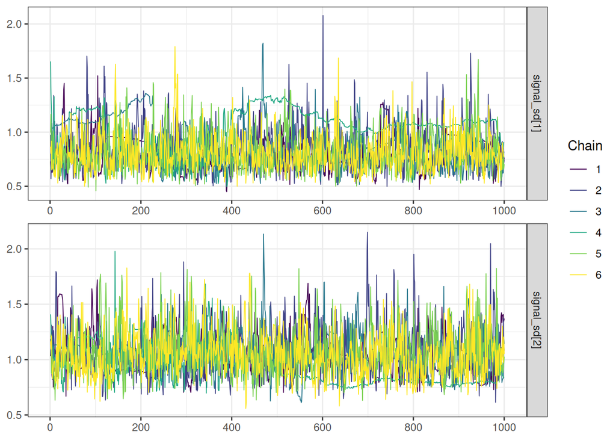

```r
mcmc_trace(output$draws(sampled_vars), pars = vars(starts_with("signal")),
           facet_args = list(nrow = 2, strip.position = "right"))
```

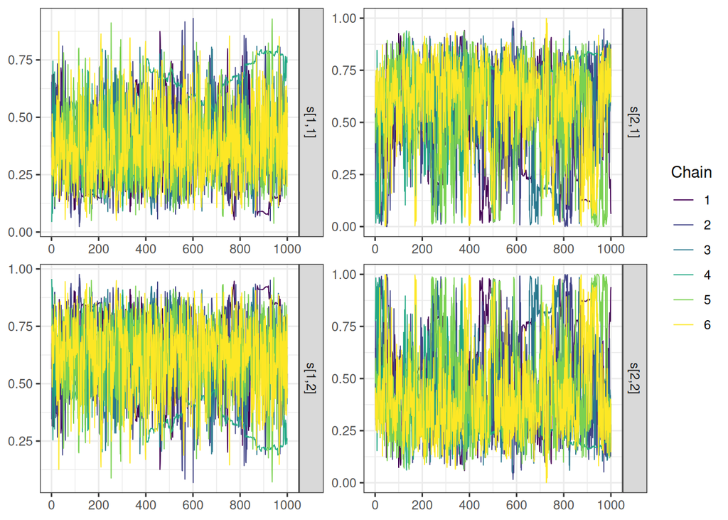

```r
mcmc_trace(output$draws(sampled_vars), pars = vars(starts_with("s[")),
           facet_args = list(nrow = 3, strip.position = "right", dir = "lt"))
```

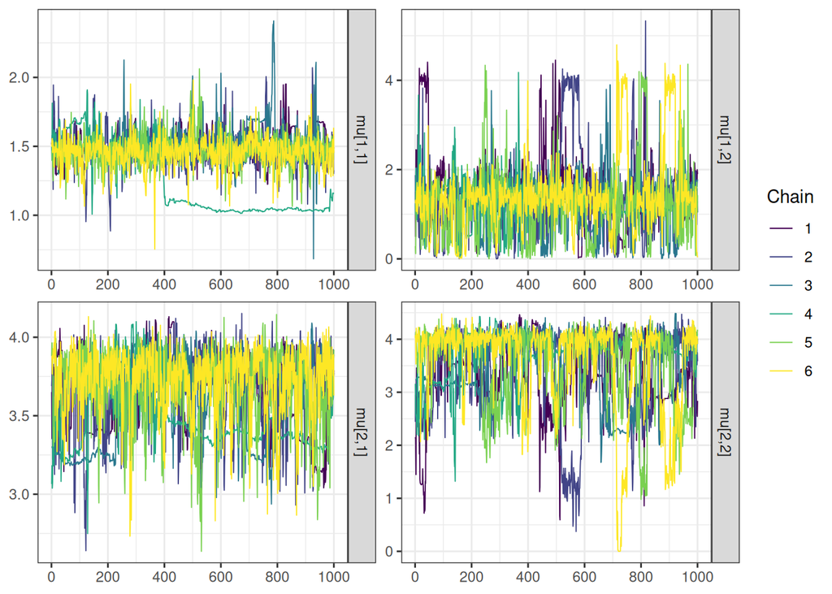

```r
mcmc_trace(output$draws(sampled_vars), pars = vars(starts_with("mu")),
           facet_args = list(ncol = 2, strip.position = "right", dir = "tl"))
```

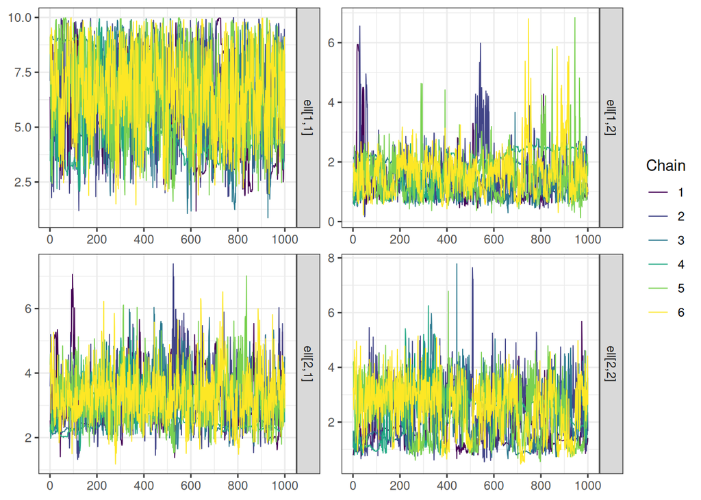

```r
mcmc_trace(output$draws(sampled_vars), pars = vars(starts_with("ell")),
           facet_args = list(ncol = 2, strip.position = "right", dir = "tl"))
```

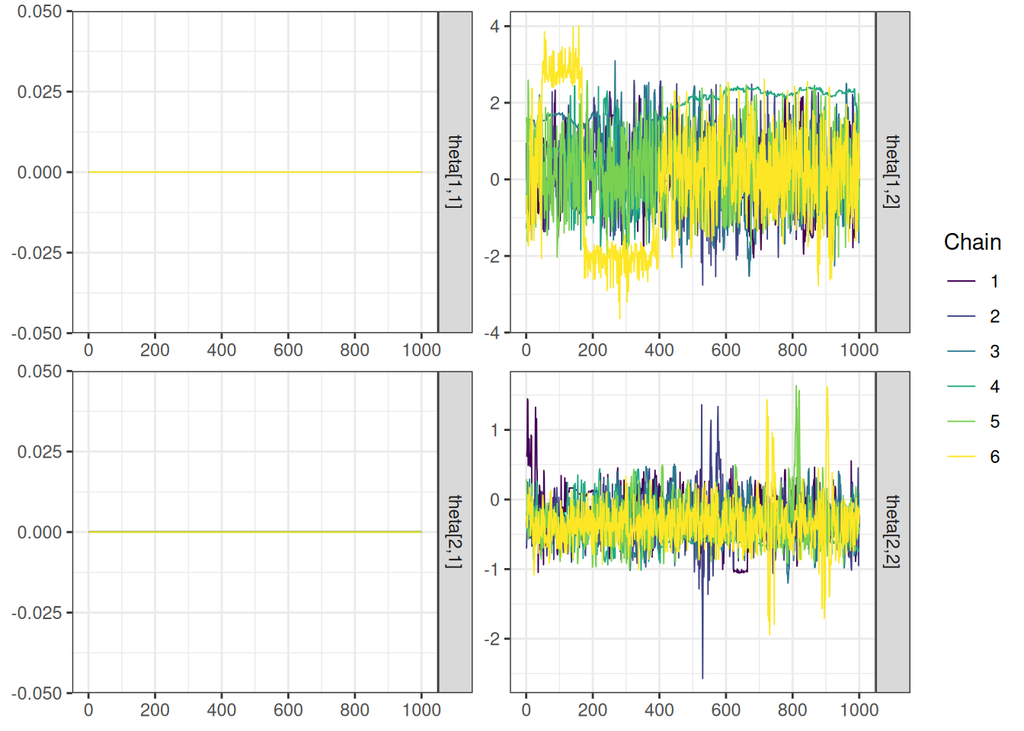

```r
mcmc_trace(output$draws(sampled_vars), pars = vars(starts_with("theta")),
           facet_args = list(ncol = 2, strip.position = "right", dir = "tl"))
```

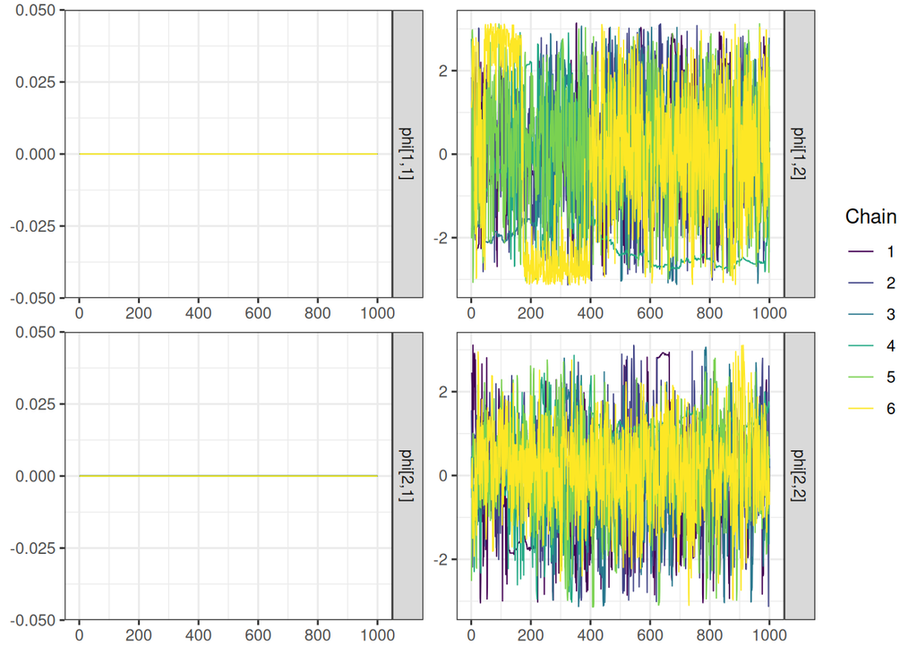

```r
mcmc_trace(output$draws(sampled_vars), pars = vars(starts_with("phi")),
           facet_args = list(ncol = 2, strip.position = "right", dir = "tl"))
```

## Valid Chains

```r
valid_chains <- c(2,5)

output_draws <- output$draws(variables = all_vars, format = "df") |>
  subset_draws(chain = valid_chains)
output_draws_mat <- as.matrix(output_draws)

summarise_draws(output_draws, default_convergence_measures())
```

```
# A tibble: 34 × 4
   variable    rhat ess_bulk ess_tail
   <chr>      <dbl>    <dbl>    <dbl>
 1 w[1,1]      1.00    899.     812.
 2 w[2,1]      1.00   1012.    1019.
 3 w[1,2]      1.01    151.     141.
 4 w[2,2]      1.00    898.    1013.
 5 mu[1,1]     1.00    554.     671.
 6 mu[2,1]     1.01    179.     421.
 7 mu[1,2]     1.02    112.      43.5
 8 mu[2,2]     1.02     72.1     28.5
 9 Sigma[1,1]  1.01    450.     608.
10 Sigma[2,1]  1.01    194.     560.
# ℹ 24 more rows
```

## Posterior Predictive Check

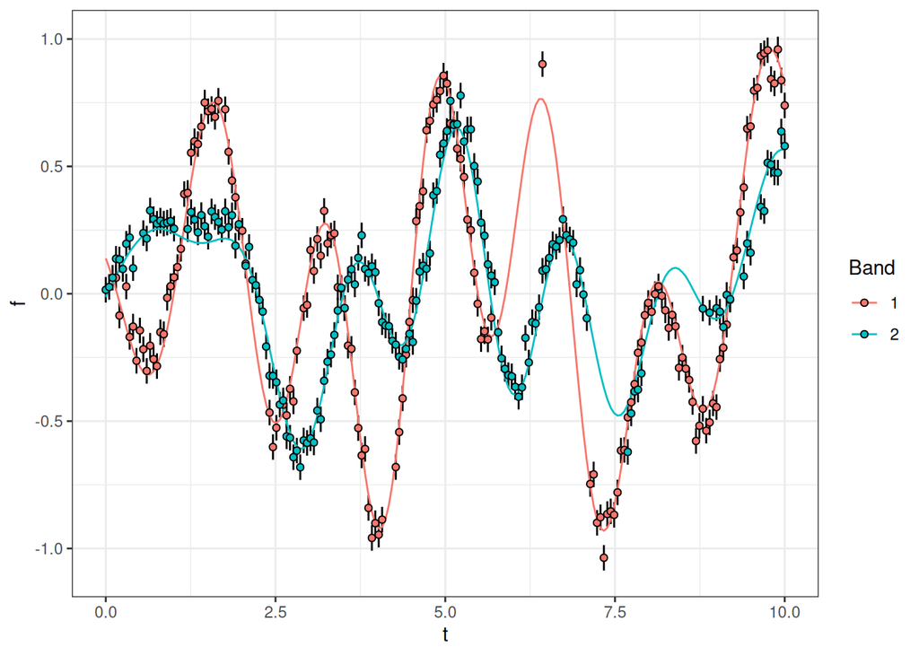

```r
n_star <- 200
ts1 <- seq(from = 0, to = 10, length.out = n_star)
ts2 <- ts1

# Draw posterior predictive samples using a particular posterior draw
post_draw <- as.data.frame(output_draws[sample.int(nrow(output_draws_mat), 1),])

pp_draw <- pred_D2_Q_draw(post_draw,
                          Q = Q,
                          t1 = band1_df$t,
                          t2 = band2_df$t,
                          y1 = band1_df$y_std,
                          y2 = band2_df$y_std,
                          y1_se = band1_df$y_se_std,
                          y2_se = band2_df$y_se_std,
                          ts1 = ts1, ts2 = ts2)

mean_colvec <- rep(c(band1_y_mean, band2_y_mean), times = c(length(ts1), length(ts2)))
sd_colvec <- rep(c(band1_y_sd, band2_y_sd), times = c(length(ts1), length(ts2)))

ggplot() +
  geom_linerange(data = input_df,
                 mapping = aes(x = t, ymax = y + y_se, ymin = y - y_se), colour = "black") +
  geom_line(data = pp_draw,
            mapping = aes(x = ts, y = fs*sd_colvec + mean_colvec, colour = d)) +
  geom_point(data = input_df, mapping = aes(x = t, y = y, fill = d), shape = 21, size = 1.5) +
  labs(colour = "Band", fill = "Band", y = "f")
```

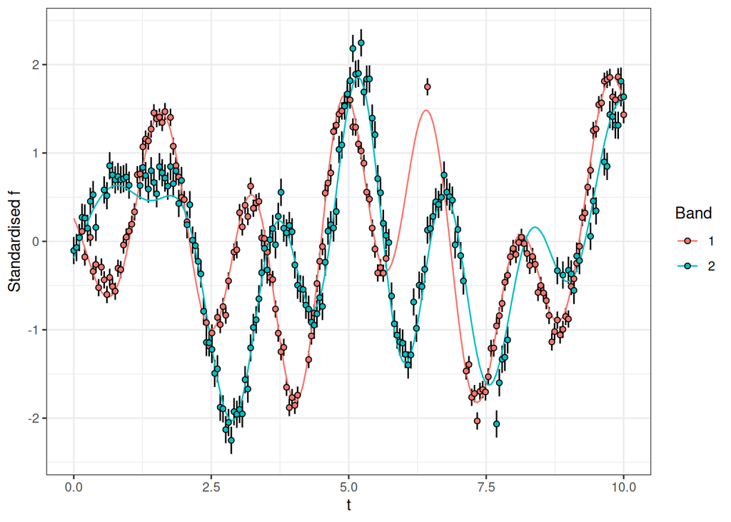

```r
ggplot() +
  geom_linerange(data = input_df,
                 mapping = aes(x = t,
                               ymax = y_std + y_se_std,
                               ymin = y_std - y_se_std),
                 colour = "black") +
  geom_line(data = pp_draw, aes(x = ts, y = fs, colour = d)) +
  geom_point(data = input_df,
             mapping = aes(x = t, y = y_std, fill = d), shape = 21, size = 1.5) +
  labs(colour = "Band", fill = "Band", y = "Standardised f")
```

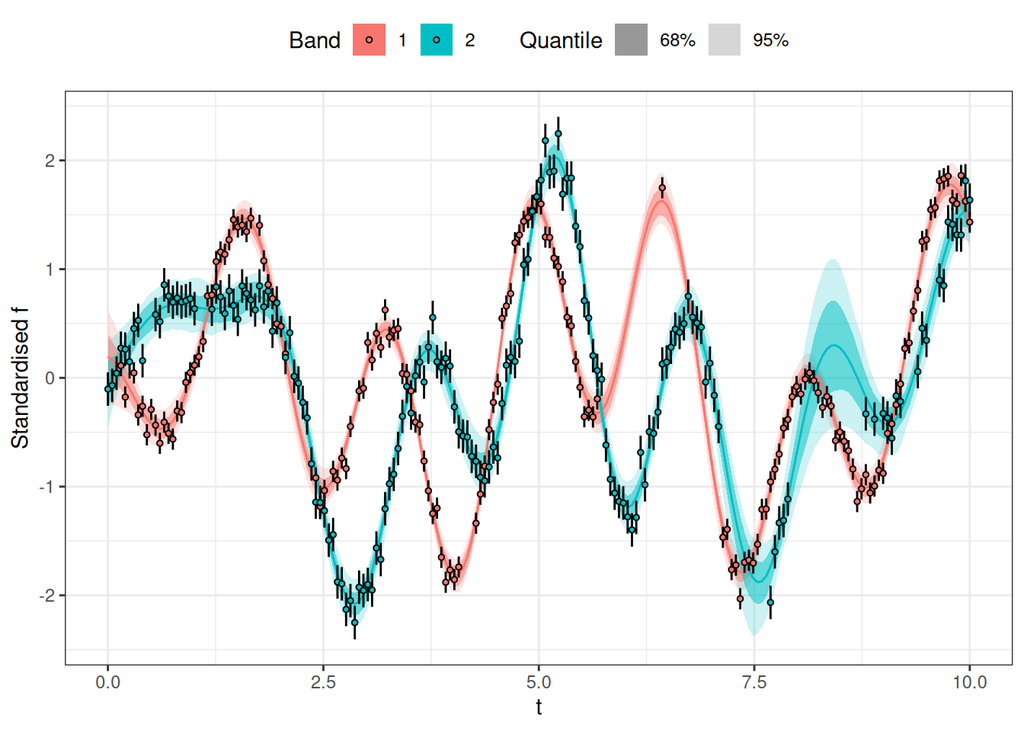

```r
pp_draws <- pred_D2_Q(draws = output_draws,
                      Q = Q,
                      t1 = band1_df$t,
                      t2 = band2_df$t,
                      y1 = band1_df$y_std,
                      y2 = band2_df$y_std,
                      y1_se = band1_df$y_se_std,
                      y2_se = band2_df$y_se_std,
                      ts1 = ts1,
                      ts2 = ts2,
                      n_draws = 100)

pp_draws |>
  summarise(.by = c(d, ts),
            Mean = mean(fs),
            Q2.5 = quantile(fs, probs = 0.025),
            Q97.5 = quantile(fs, probs = 0.975),
            Q16 = quantile(fs, probs = 0.16),
            Q84 = quantile(fs, probs = 0.84)) |>
  ggplot() +
  aes(x = ts, fill = d) +
  geom_ribbon(aes(ymin = Q2.5, ymax = Q97.5, alpha = "95%")) +
  geom_ribbon(aes(ymin = Q16, ymax = Q84, alpha = "68%")) +
  geom_line(aes(colour = d, y = Mean), alpha = 1) +
  geom_linerange(data = input_df, mapping = aes(x = t, ymax = y_std + y_se_std, ymin = y_std - y_se_std), colour = "black") +
  geom_point(data = input_df, mapping = aes(x = t, y = y_std, fill = d), shape = 21, size = 1) +
  scale_alpha_manual(values = c(`95%` = 0.2, `68%` = 0.5)) +
  labs(colour = "Band", fill = "Band", alpha = "Quantile",
       y = "Standardised f", x = "t", ) +
  theme(legend.position = "top")
```

## Hyperparameter Posteriors

```r
print(input_params) # ground truth
```

```
$seed
[1] 8641

$w
     [,1]   [,2]
[1,]  1.0 0.8944
[2,]  0.7 0.5000

$mu
     [,1] [,2]
[1,]  1.5  1.6
[2,]  4.0  4.1

$Sigma
     [,1]   [,2]
[1,] 0.01 0.0144
[2,] 0.04 0.0400

$theta
     [,1] [,2]
[1,]    0  0.5
[2,]    0 -0.3

$phi
     [,1] [,2]
[1,]    0    0
[2,]    0    0
```

```r
posterior_means <- as.data.frame(output_draws) |>
  dplyr::select(matches(all_vars), -.draw) |>
  colMeans()
posterior_means |> round(3)
```

```
      w[1,1]       w[2,1]       w[1,2]       w[2,2]      mu[1,1]      mu[2,1]
       0.801        0.731        0.575        0.640        1.475        3.676
     mu[1,2]      mu[2,2]   Sigma[1,1]   Sigma[2,1]   Sigma[1,2]   Sigma[2,2]
       1.312        3.487        0.035        0.117        0.819        0.354
  theta[1,1]   theta[2,1]   theta[1,2]   theta[2,2]     phi[1,1]     phi[2,1]
       0.000        0.000        0.245       -0.329        0.000        0.000
    phi[1,2]     phi[2,2] signal_sd[1] signal_sd[2]       s[1,1]       s[2,1]
       0.087        0.155        0.837        1.062        0.380        0.540
      s[1,2]       s[2,2]       v[1,1]       v[2,1]       v[1,2]       v[2,2]
       0.620        0.460        0.275        0.460        0.628        0.544
    ell[1,1]     ell[2,1]     ell[1,2]     ell[2,2]
       6.598        3.208        1.550        2.373
```

```r
posterior_modes <- sapply(dplyr::select(as.data.frame(output_draws), matches(all_vars), -.draw), estimate_mode)
posterior_modes |> round(3)
```

```
      w[1,1]       w[2,1]       w[1,2]       w[2,2]      mu[1,1]      mu[2,1]
       0.650        0.633        0.529        0.530        1.488        3.803
     mu[1,2]      mu[2,2]   Sigma[1,1]   Sigma[2,1]   Sigma[1,2]   Sigma[2,2]
       1.392        4.060        0.012        0.084        0.748        0.135
  theta[1,1]   theta[2,1]   theta[1,2]   theta[2,2]     phi[1,1]     phi[2,1]
      -0.009       -0.009        0.069       -0.361       -0.009       -0.009
    phi[1,2]     phi[2,2] signal_sd[1] signal_sd[2]       s[1,1]       s[2,1]
       0.434        0.162        0.790        0.949        0.329        0.662
      s[1,2]       s[2,2]       v[1,1]       v[2,1]       v[1,2]       v[2,2]
       0.671        0.338        0.150        0.286        0.430        0.298
    ell[1,1]     ell[2,1]     ell[1,2]     ell[2,2]
       6.390        2.968        0.918        1.123
```

# Discussion

## Checking `s`, $s$

`s[q,i]` is the share of a band’s signal variance carried by each component.

```r
print_param_est(output_draws, "s", D, Q)
```

```
            Band 1    Band 2
Component 1 0.3796786 0.5395493
Component 2 0.6203214 0.4604507
```

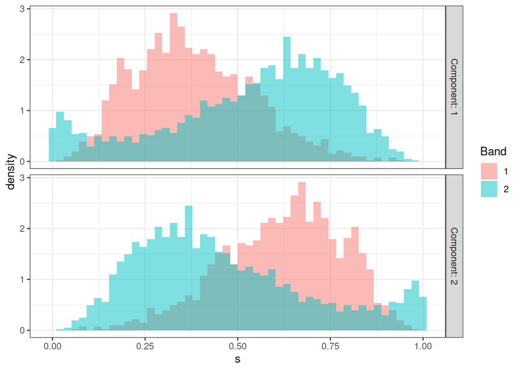

```r
plot_draw_histograms(output_draws, "s")
```

Both components have reasonable shares of the total variance in each band.

## Checking $\ell$

Coherence length is $\ell = \frac{1}{\sqrt{\Sigma}}$. There cannot be a stable cross-covariance if two oscillators already drift out of phase within just one coherence length. Long coherence lengths (narrow spectral peaks) make the $\mu$ gap matter more, short coherence lengths (broad spectral peaks) make the gap matter less.

```r
print_param_est(output_draws, "ell", D, Q)
```

```
            Band 1   Band 2
Component 1 6.598138 1.550028
Component 2 3.208471 2.37255
```

```r
print_param_est(output_draws, "ell", D, Q, estimate_mode)
```

```
            Band 1   Band 2
Component 1 6.389991 0.9175699
Component 2 2.968184 1.122897
```

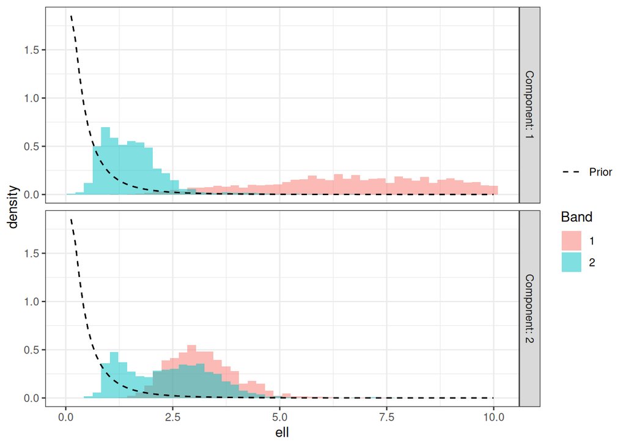

```r
plot_draw_histograms(output_draws, "ell") +
  #scale_x_continuous(transform = "log10", labels = scales::label_number()) +
  geom_function(fun = dlnorm,
                args = list(meanlog = ell_loc, sdlog = ell_scale),
                mapping = aes(colour = "Prior"),
                linetype = "dashed") +
  scale_colour_manual(values = "black") +
  labs(colour = "")
```

Coherence length scales in Components 1 and 2 are distinct from zero, i.e., $\ell$ does not appear to be pushed up against any bounds or degerated to zero.

## Checking coupling between bands within components

How well the frequencies in the two bands line up within a component, i.e., a frequency overlap factor on [0,1].

Coupling = 1 suggests both bands oscillate at same frequency. Coupling = 0 means two frequency peaks do not overlap, i.e., no shared structure between bands.

```r
ds <- output$draws(c("mu", "Sigma"), format = "matrix") |> subset_draws(chain = valid_chains)

z_coupling <- function(q, d) {
  mu1 <- d[, paste0("mu[", q, ",1]")]
  mu2 <- d[, paste0("mu[", q, ",2]")]
  S1  <- d[, paste0("Sigma[", q, ",1]")]
  S2  <- d[, paste0("Sigma[", q, ",2]")]
  z <- abs(mu1 - mu2) / (2 * sqrt(S1 + S2))
  exp(-z^2) # peak coupling between the two bands
}

coup <- sapply(1:Q, function(q) quantile(z_coupling(q, ds), c(0.05, 0.5, 0.95)))
colnames(coup) <- paste("Component", 1:Q)
round(coup, 2)
```

```
    Component 1 Component 2
5%         0.10        0.48
50%        0.95        0.92
95%        1.00        1.00
```

There appears to be sufficient coupling within components.

## Interpreting `signal_sd`

$S_i$ is the total standard deviation of the signal in each band, here: $i = 1,2$.

```r
print_param_est(output_draws, "signal_sd", D, Q)
```

```
 Band 1   Band 2
 0.836945 1.062112
```

```r
print_param_est(output_draws, "signal_sd", D, Q, estimate_mode)
```

```
 Band 1    Band 2
 0.7899411 0.9487633
```

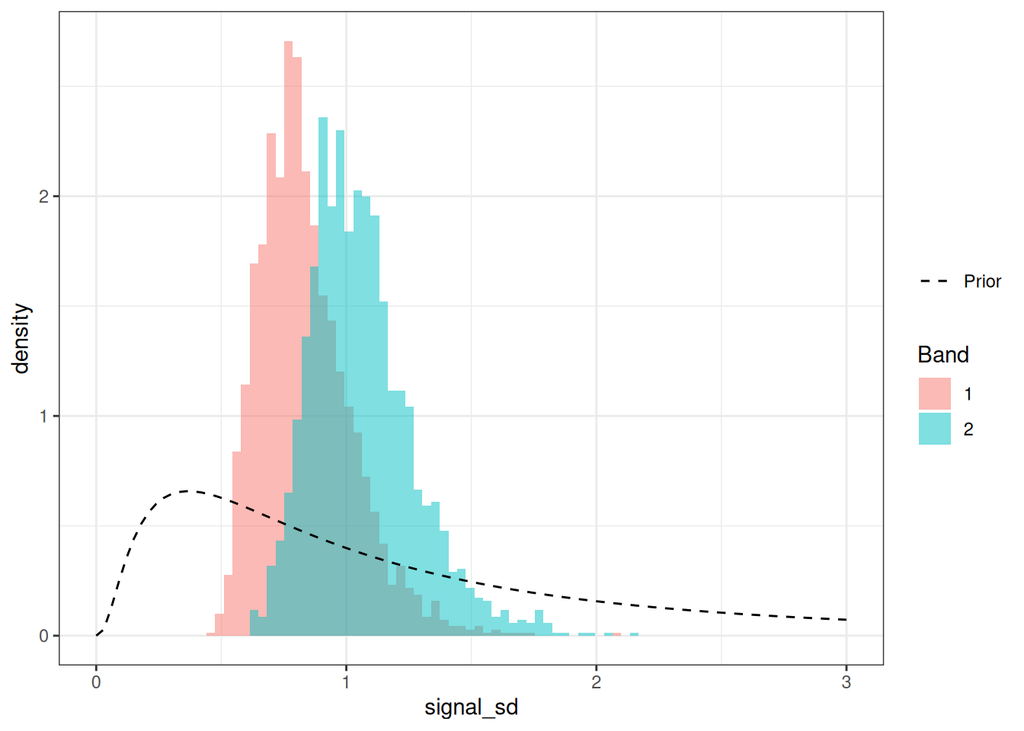

```r
output_draws |>
  as.data.frame() |>
  dplyr::select(.draw, starts_with("signal")) |>
  pivot_longer(2:3) |>
  separate_wider_position(cols = name,  width = c("p" = 9, 1, "Band" = 1, 1)) |>
  ggplot() +
  geom_histogram(mapping = aes(x = value, fill = Band, y = after_stat(density)),
                 bins = 50,
                 position = "identity",
                 alpha = 0.5) +
  geom_function(fun = dlnorm,
                args = list(sdlog = signal_sd_scale),
                mapping = aes(colour = "Prior"),
                linetype = "dashed",
                xlim = c(0, 3)) +
  scale_colour_manual(values = "black") +
  labs(x = "signal_sd", colour = "")
```

Recalling that the response variable $y$ has been standardised, we expect the total standard deviation of each band to be close to 1, which it is.

## Interpreting $\Sigma$

$\Sigma$s refer to the widths of the bumps in the spectral domain centred at the $\mu$s.

```r
print_param_est(output_draws, "Sigma", D, Q)
```

```
            Band 1     Band 2
Component 1 0.03534041 0.8188573
Component 2 0.1172552  0.3535263
```

```r
print_param_est(output_draws, "Sigma", D, Q, estimate_mode)
```

```
            Band 1     Band 2
Component 1 0.01175198 0.7475469
Component 2 0.08442069 0.1354981
```

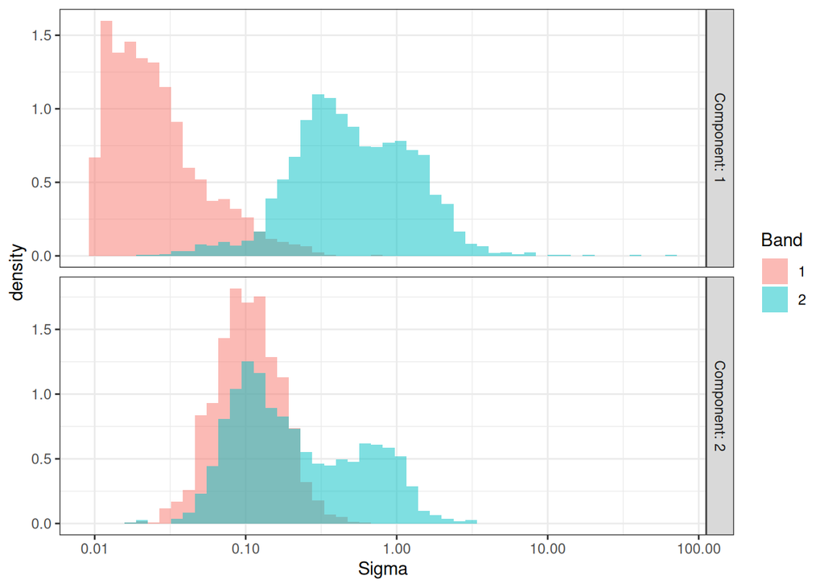

```r
plot_draw_histograms(output_draws, "Sigma") +
  scale_x_continuous(transform = "log10", labels = scales::label_number())
```

## Interpreting $w$ and $v$

$w$ is the *amplitude* of the spectral component $q$ in band $i$ (standardised units).

```r
print_param_est(output_draws, "w", D, Q, estimate_mode)
```

```
            Band 1    Band 2
Component 1 0.6495926 0.5286122
Component 2 0.6325417 0.5295599
```

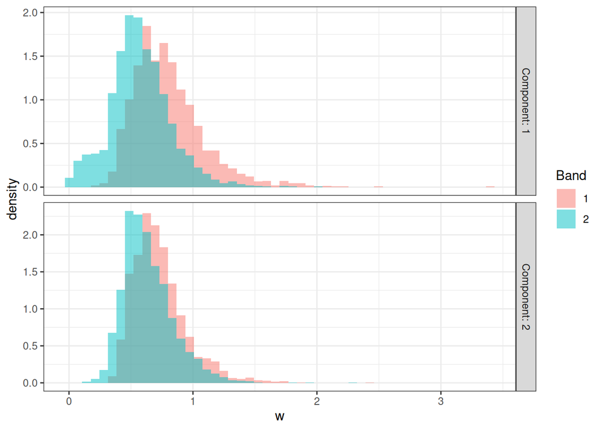

```r
plot_draw_histograms(output_draws, "w")
```

Components 1 and 2’s $w$s are distinct from zero.

It is easier to interpret the kernel (amplitude) variance in the time domain, instead of the (amplitude) magnitude in the spectral domain. Indeed, in this model, $w$ is a derived quantity from $v$.

$v(q,i)$ is the amount of variance contributed by component $q$ to band $i$.

```r
print_param_est(output_draws, "v", D, Q)
```

```
            Band 1    Band 2
Component 1 0.2750545 0.6278554
Component 2 0.4602621 0.5439756
```

```r
print_param_est(output_draws, "v", D, Q, estimate_mode)
```

```
            Band 1   Band 2
Component 1 0.149802 0.4296275
Component 2 0.28581  0.2982607
```

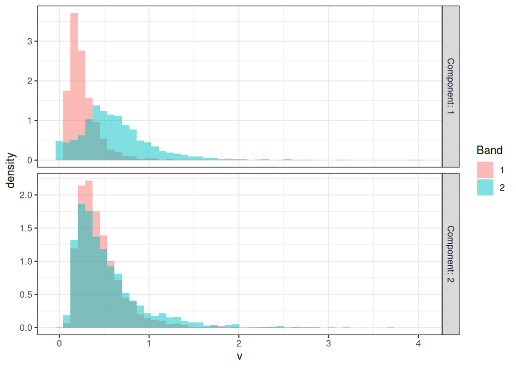

```r
plot_draw_histograms(output_draws, "v")
```

## Interpreting $\mu$s

```r
print_param_est(output_draws, "mu", D, Q)
```

```
            Band 1   Band 2
Component 1 1.475222 1.311811
Component 2 3.675975 3.487462
```

Each cell `mu[q, i]` indicates the dominant oscillation frequency (radians/unit time) of the q-th (row) component in the i-th (column) band.

When each $\mu$ differs between bands (within a component), the cross-covariance has an oscillation frequency that is the variance weighted average of the two, i.e., $\mu_{ij}$ is frequency of the product of two Gaussians; pulled towards the one with the narrower peak.

As the $\mu$s become more separated within a component, the component is really just two unrelated oscillators. In such cases, $\theta$ and $\phi$ are no longer meaningful and just reflect their priors.

If cross-covariance is zero, then there’s insufficient information to estimate $\theta$ or $\phi$. $\mu$s are still identifiable but this component is really two unrelated oscillators, i.e., there is no shared signal to be delayed between bands.

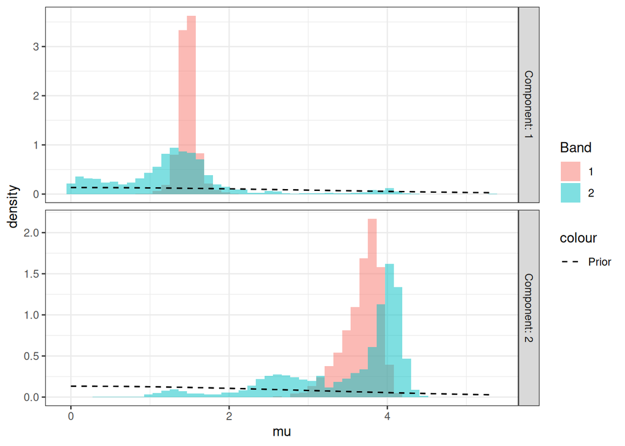

```r
plot_draw_histograms(output_draws, "mu") +
  geom_function(fun = dnorm,
                args = list(sd = mu_scale),
                mapping = aes(colour = "Prior"),
                linetype = "dashed") +
  scale_colour_manual(values = "black")
```

## Interpreting $\theta$s

Entry `theta[q,i]` is band `i`’s (column) time shift within component `q` (row).

A delay is only meaningful relative to how fast the cross-covariance decays.

```r
input_params$theta
```

```
     [,1] [,2]
[1,]    0  0.5
[2,]    0 -0.3
```

```r
print_param_est(output_draws, "theta", D, Q, estimate_mode)
```

```
            Band 1       Band 2
Component 1 -0.009371675 0.06926548
Component 2 -0.009371675 -0.3605402
```

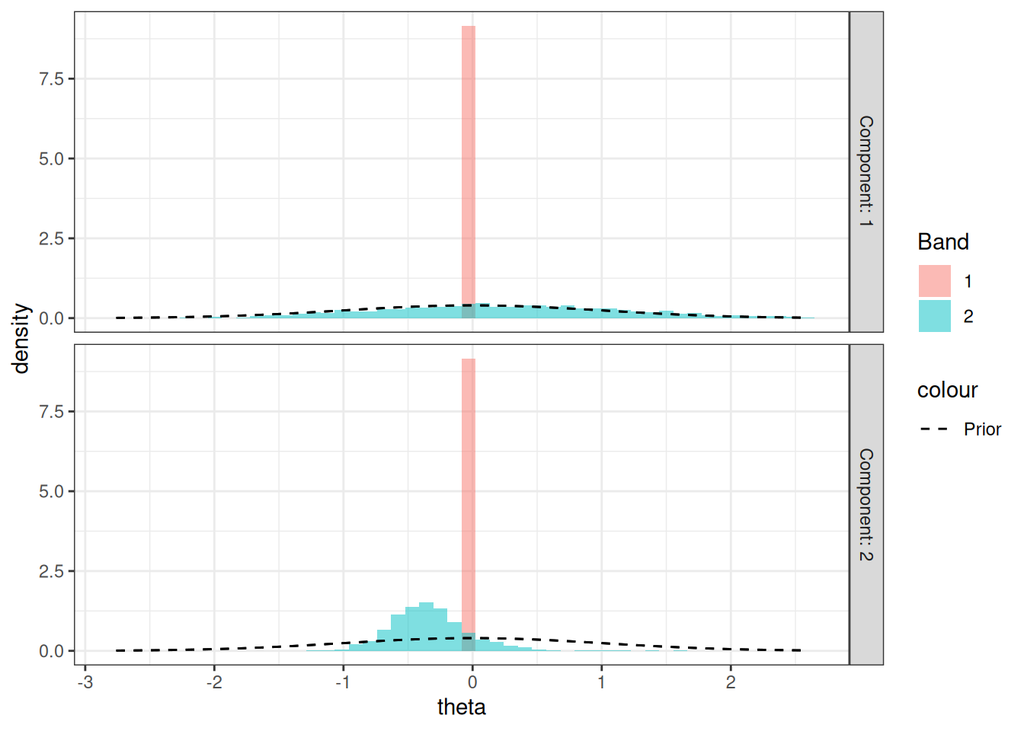

```r
plot_draw_histograms(output_draws, "theta") +
  geom_function(fun = dnorm,
                args = list(sd = theta_scale),
                mapping = aes(colour = "Prior"),
                linetype = "dashed") +
  scale_colour_manual(values = "black")
```

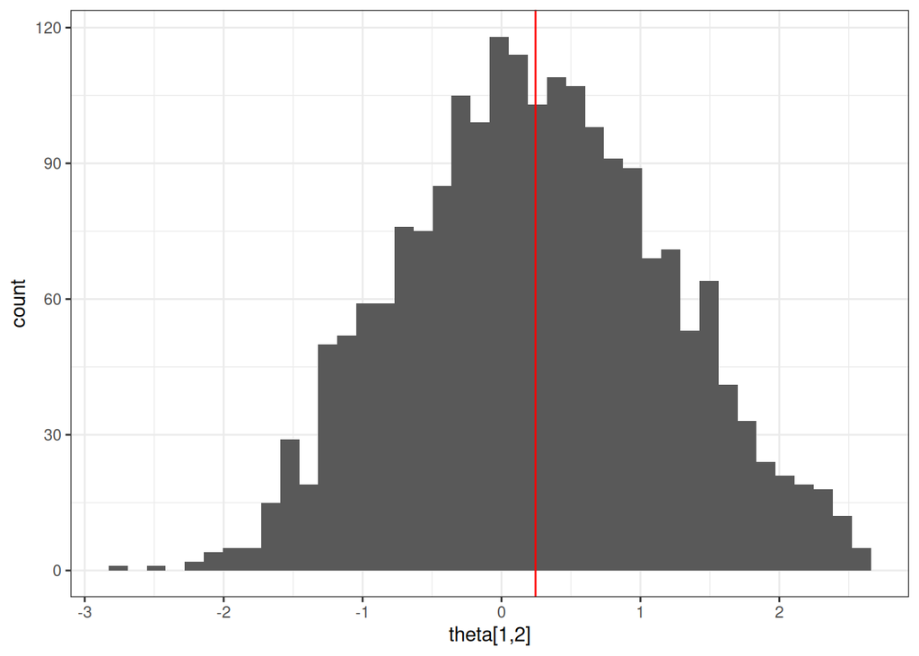

```r
output_draws |>
  ggplot() +
  aes(x = `theta[1,2]`) +
  geom_histogram(bins = 40) +
  geom_vline(xintercept = posterior_means["theta[1,2]"], colour = "red")
```

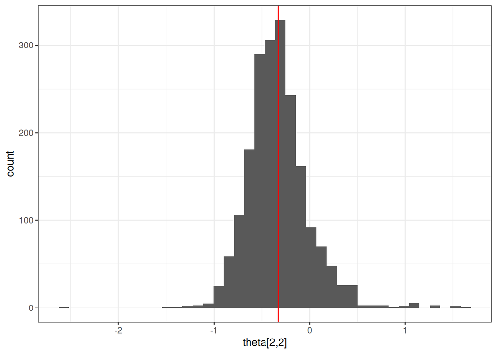

```r
output_draws |>
  ggplot() +
  aes(x = `theta[2,2]`) +
  geom_histogram(bins = 40) +
  geom_vline(xintercept = posterior_means["theta[2,2]"], colour = "red")
```

Band 2 appears later than Band 1.

## Interpreting $\phi$s

```r
input_params$phi
```

```
     [,1] [,2]
[1,]    0    0
[2,]    0    0
```

```r
print_param_est(output_draws, "phi", D, Q, estimate_mode)
```

```
            Band 1       Band 2
Component 1 -0.009371675 0.4342085
Component 2 -0.009371675 0.1623319
```

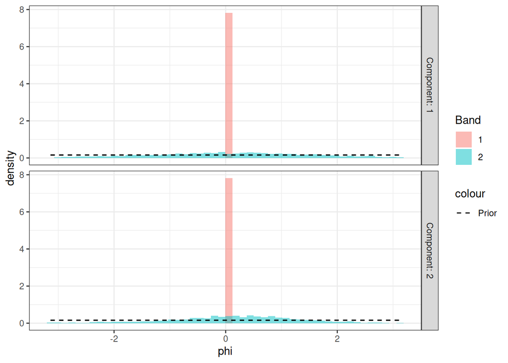

```r
plot_draw_histograms(output_draws, "phi") +
  geom_function(fun = dunif,
                args = list(min = -pi, max = pi),
                mapping = aes(colour = "Prior"),
                linetype = "dashed") +
  scale_colour_manual(values = "black")
```

The $\phi$s are indistinguishable from noise.